# Downloading station data from the DWD and basic usage

Philipp Müller

2016-12-24

# About

This vignette gives an introduction into two of the main purposes of the **climex** package:

1. Downloading and formatting of all the station data provided by the German weather service (DWD)
2. Preprocessing of the time series and fitting of the generalized extreme value (GEV) distributions

The usage of the shiny based climex web app will be covered in another vignette.

# Downloading and formatting of the station data of the DWD

Since this package is intended to be used on climate data it comes along with a function to download and format all station data provided by the [German weather service (DWD)](http://www.dwd.de/DE/Home/home_node.html). I chose the daily measured time series since a higher temporal resolution would not make much sense in the context of extreme value analysis.

Before using the data please read the terms of use of the DWD carefully.

The package as well as its shiny app can be used without downloading the data of the DWD. So if you already have your own data base feel free to skip to the next chapter.

## Prerequisites

First of all the global variable **CLIMEX.PATH** has to be set. Just add the following lines to ~/.Rprofile

```r
## example path. Feel free to choose your own.
CLIMEX.PATH <<- "~/R/climex/"
if ( !dir.exists( CLIMEX.PATH ) )
    dir.create( CLIMEX.PATH, recursive = TRUE )
```

This folder will contain the downloaded station data as well as the all the assets needed to deploy the climex web app locally.

## Downloading

In the second step open a new R shell, load the climex package and run the *download.data.dwd()* function to download and format the station data.

```r
require( climex )
download.data.dwd() # this will take a while
```

This will create a folder in **CLIMEX.PATH** called **download_dwd** containing the mirrored content of the daily measured station data from the DWD’s FTP server. Those .zip files will be extracted, parsed and converted to the *xts* format one after another. The parsing takes some time and can last for several minutes depending on your machines specifications. To avoid saving the data the argument *save.downloads* can be set to FALSE. But it is recommended to set it to TRUE since the function will compare the time stamps of the files on the FTP server against the ones of the local copies. Running this function another time will thus update your existing data base.

Per default three different types of data will be extracted: the daily maximal and minimal temperature and the daily precipitation. Using the *data.type* argument one can obtain a variety of additional information from the DWD data base. There are several stations with missing data or for which specific types of measurements are not available at all. In the original time series those were set to -999 but during the formatting they are replaced by NA to avoid numerical artifacts. Please be aware that these steps will use the *mclapply* function of the **parallel** package starting threats on all your machine’s cores to enhance the speed of the import.

After parsing the data it will be saved as lists of objects of the class **xts** and written to the CLIMEX.PATH/dwd_downloads folder in R’s binary format .RData.

In addition there is the *csv.export* option exporting the lists of xts data to .csv files which can be imported into any other application. For each chosen data source in the data.type character vector a new folder will be created containing the data of each single station in a different file.

## Loading the data

Since the data will be stored you do not have to repeat this step every time you want to load the data.

```r
source.data( pick.default = TRUE )
```

If the *pick.default* option is set to TRUE it will just look for the default station data (containing the maximum and minimum daily temperature as well as the daily precipitation). If the option is set to FALSE an interactive choice we be prompted instead. This will print all existing .RData files in the CLIMEX.PATH/dwd_downloads folder and let the user choose which one to import using an interactive prompt. As an alternative one of course can just use the plain *load()* function.

# Preprocessing and fitting of the GEV distribution

The second part of this vignette shows the basic usage of the package’s function for preprocessing the time series and fitting the generalized extreme value (GEV) distributions. It will use the daily maximum temperature time series of the Potsdam station also contained in the data set downloaded in the first part.

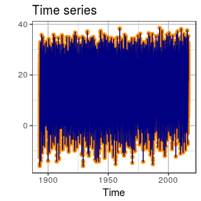

```r
require( climex )
data( temp.potsdam )

## convenience function for plotting xts class time series using ggplot2
ttplot( temp.potsdam )
```

## Preprocessing

The essence of the extreme value analysis is either to split a time series in blocks and extract their maximal values or to extract all data points above a specific threshold.

For the first approach it is quite important to make sure the time series is composed of complete years only. Imagine we extract the annual maximum of each year in the time series but the time series starts in autumn (and resides on the northern hemisphere). This would result in the first annual maximum to be significant lower than all the others and cause the analysis to yield wrong results.

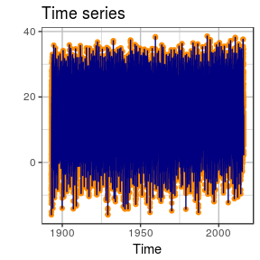

```r
temp.potsdam.complete <- remove.incomplete.years( temp.potsdam )

ttplot( temp.potsdam.complete )
```

If we would deal with all the different station data of the DWD downloaded in the first section an additional second step discarding all time series containing less than 30 years would be required. Since we want to extract the annual maxima we would end up with less than 30 points to fit the three GEV parameters in a later step.

One of the basic assumptions within the extreme value theory is that the time series is stationary and does not contain any correlations. It is a rather bold approximation (especially in the context of the climate change) but we will assume here that the time series is indeed stationary and does not have long-range correlations. But there is still a very prominent short-range correlation present in the temperature: the annual cycle. We will get rid of it by calculating the anomalies. Therefore we calculate the mean value of each day and subtract it from the individual ones.

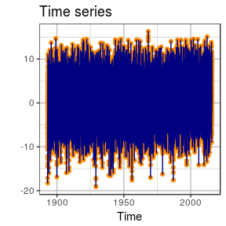

```r
temp.potsdam.anomalies <- anomalies( temp.potsdam.complete )

ttplot( temp.potsdam.anomalies )
```

Though you have way more data contributing to the analysis (you can not expect the hottest day of the year to occur during winter) and thus the asymptotic properties of the GEV distribution are more likely fulfilled the interpretation of extremes in temperature anomalies is more difficult than in the raw series.

## Fitting the GEV distribution

After the preprocessing we will separate the time series in annual blocks and extract their maximal values.

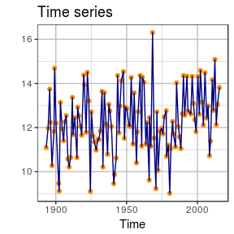

```r
## Per default the block length of the block() function will be one year
temp.potsdam.blocked <- block( temp.potsdam.anomalies )

ttplot( temp.potsdam.blocked )
```

In a last step we will fit a GEV distribution onto the time series and use the fitting result to calculate the 100 year return level of the stations temperature anomalies.

```r
## The result will be a list of objects similar to the output of the
## optim function.
gev.potsdam <- climex::gev.fit( temp.potsdam.blocked )

return.level.potsdam <- climex::rlevd( gev.potsdam )
print( return.level.potsdam )
```

```
## [1] 15.56369
```

## Note

I highly recommend not to use just the command line interface of the package but also its web app which contains a variety of tools to check the validity of the fit.

During my work I focused on the GEV distribution and the blocking approach in extreme value theory. If you are more into the threshold one and the generalized Pareto (GP) distribution please use the *ismev::gpd.fit()* function instead of *climex::gev.fit()*. Support of this approach will probably be added in a future release.

# Distinction from other packages fitting GEV distributions

Okay, so far so good. But **why** to use this package instead of all the other R packages out there performing both the GEV and GP fit?

1. The package’s web application provides a interface which make it quite easily to work with a lot of time series, to try a lot of different approaches in the preprocessing and fitting and it features a map-based visualization enabling the user to compare results across different geographical locations.
2. In most packages (like **ismev**, **texmex**, **fExtremes**) the focus is in the handling of the time series but not on the fitting itself. They just call the optim function with its default values and use of poor heuristic to determine the initial parameters to start the optimization. The **extRemes** package is the most advanced package handling extreme events and contains a more sophisticated heuristic for the initial parameters. But it calls the optim function to use the **BFGS** optimization routine instead of the default **Nelder-Mead** one. In this package the focus lies on the most appropriate fitting procedure including an even more sophisticated heuristic and a lot of thoughts in the called fitting routine (I am about to submit a paper covering those aspects. More info soon). In the end its the correctness of the result that matters most.